# EXPLO : Statistiques exploratoires

3. Analyse en composantes principales (ACP)

Auteur·rice

Sophie Baudet-Michel, Claude Grasland

Date de publication

2024-05-13

```r
## Packages utilitaire
library(knitr)
library(dplyr,quiet=T)

### Package d'analyse des données
library(FactoMineR)

### Packages de cartographie
library(sf, quietly-TRUE)
library(mapsf)
library(RColorBrewer)
```

## (3) ANALYSE EN COMPOSANTES PRINCIPALES (ACP)

Au vu de l’exploration statistique, on a décidé de transformer la densité de population en logarithme. Le reste des variables demeure inchangé. On choisit comme précédemment l’exemple de la situation en 2004.

### Tableau brut

On constitue un tableau ne gardant que les 6 variables utiles. On ajoute en nom de lignes le code des gouvernorats

```r
don<-readRDS("EXPLO/don2004.RDS")

# transforme la densité
don$logden<-log(don$densi)

# choisit les variables
tab<-don[,c("tailm", "logden","mobil", "acmig", "ordin","porta")]

# Ajoute un identifiant en numéro de ligne
row.names(tab) <- don$code

# Affiche le tableau
kable(tab, digits=2, caption = "Tableau brut")
```

Tableau brut

|  | tailm | logden | mobil | acmig | ordin | porta |
| --- | --- | --- | --- | --- | --- | --- |
| AN | 4.17 | 6.92 | 21.85 | 8.97 | 16.32 | 59.31 |
| BA | 4.29 | 6.65 | 24.06 | 7.30 | 13.02 | 60.50 |
| BJ | 4.44 | 4.40 | 10.56 | -3.15 | 3.24 | 32.19 |
| BZ | 4.37 | 5.01 | 9.85 | -0.54 | 4.98 | 38.72 |
| GB | 4.92 | 3.87 | 14.71 | -0.69 | 6.00 | 46.11 |
| GF | 4.91 | 3.72 | 11.22 | -2.40 | 6.81 | 43.60 |
| JE | 4.49 | 4.90 | 10.11 | -2.38 | 2.50 | 32.93 |
| KB | 5.39 | 1.85 | 9.99 | -1.20 | 3.38 | 50.70 |
| KF | 4.38 | 3.93 | 13.73 | -4.31 | 3.04 | 33.02 |
| KR | 5.06 | 4.42 | 9.78 | -4.21 | 1.72 | 29.51 |
| KS | 5.19 | 3.91 | 9.73 | -4.10 | 1.60 | 31.19 |
| ME | 4.81 | 3.85 | 11.87 | 0.62 | 4.69 | 49.46 |
| MH | 4.77 | 4.88 | 7.35 | -0.65 | 3.32 | 42.78 |
| MN | 4.75 | 5.71 | 14.63 | 2.89 | 6.61 | 43.52 |
| MS | 4.51 | 6.13 | 11.19 | 3.72 | 7.81 | 56.02 |
| NB | 4.27 | 5.50 | 9.22 | 1.02 | 6.10 | 46.51 |
| SF | 4.31 | 4.81 | 16.89 | 1.33 | 7.77 | 47.60 |
| SL | 4.83 | 3.92 | 12.32 | -5.00 | 2.25 | 32.68 |
| SS | 4.37 | 5.48 | 17.58 | 4.02 | 9.62 | 56.75 |
| SZ | 5.15 | 3.98 | 8.73 | -3.55 | 1.24 | 36.69 |
| TA | 5.40 | 1.31 | 13.52 | -1.71 | 3.48 | 45.79 |
| TO | 4.76 | 2.86 | 10.39 | -0.60 | 5.04 | 43.56 |
| TU | 4.03 | 8.31 | 26.38 | -2.76 | 14.01 | 60.47 |
| ZA | 4.80 | 4.03 | 9.41 | -0.49 | 2.70 | 37.94 |

### Standardisation

L’ACP normée va travailler non pas sur le tableau brut mais sur le tableau standardisé afin que les variables soient comparables. Pour éliminer les effets de taille et d’unité de mesure. Chaque variable aura alors le même poids.

```r
# applique la standardiation à chaque variable (2)
tabstd <- apply(tab,2, scale)

# Ajoute les identifiants des unités
row.names(tabstd)<-don$code

#Affiche le tableau
kable(tabstd,
      digits=1,
      caption="Tableau standardisé")
```

Tableau standardisé

|  | tailm | logden | mobil | acmig | ordin | porta |
| --- | --- | --- | --- | --- | --- | --- |
| AN | -1.3 | 1.5 | 1.8 | 2.6 | 2.6 | 1.6 |
| BA | -1.0 | 1.3 | 2.2 | 2.1 | 1.8 | 1.7 |
| BJ | -0.6 | -0.1 | -0.5 | -0.8 | -0.6 | -1.2 |
| BZ | -0.8 | 0.3 | -0.7 | -0.1 | -0.2 | -0.5 |
| GB | 0.6 | -0.5 | 0.3 | -0.1 | 0.1 | 0.2 |
| GF | 0.6 | -0.6 | -0.4 | -0.6 | 0.3 | 0.0 |
| JE | -0.5 | 0.2 | -0.6 | -0.6 | -0.8 | -1.1 |
| KB | 1.9 | -1.8 | -0.6 | -0.2 | -0.6 | 0.7 |
| KF | -0.8 | -0.4 | 0.1 | -1.1 | -0.7 | -1.1 |
| KR | 1.0 | -0.1 | -0.7 | -1.1 | -1.0 | -1.5 |
| KS | 1.3 | -0.4 | -0.7 | -1.0 | -1.0 | -1.3 |
| ME | 0.3 | -0.5 | -0.3 | 0.3 | -0.3 | 0.6 |
| MH | 0.2 | 0.2 | -1.2 | -0.1 | -0.6 | -0.1 |
| MN | 0.2 | 0.7 | 0.3 | 0.9 | 0.2 | -0.1 |
| MS | -0.4 | 1.0 | -0.4 | 1.1 | 0.5 | 1.2 |
| NB | -1.1 | 0.6 | -0.8 | 0.4 | 0.1 | 0.3 |
| SF | -1.0 | 0.1 | 0.8 | 0.5 | 0.5 | 0.4 |
| SL | 0.4 | -0.4 | -0.2 | -1.3 | -0.9 | -1.2 |
| SS | -0.8 | 0.6 | 0.9 | 1.2 | 1.0 | 1.3 |
| SZ | 1.2 | -0.4 | -0.9 | -0.9 | -1.1 | -0.8 |
| TA | 1.9 | -2.1 | 0.1 | -0.4 | -0.6 | 0.2 |
| TO | 0.2 | -1.1 | -0.6 | -0.1 | -0.2 | -0.1 |
| TU | -1.7 | 2.4 | 2.7 | -0.7 | 2.0 | 1.7 |
| ZA | 0.3 | -0.4 | -0.7 | 0.0 | -0.7 | -0.6 |

### Matrice de corrélation

On peut examiner la matrice de corrélation entre les variables :

```r
matcor<-cor(tab)
kable(matcor,digits=2, caption = "Matrice des corrélations")
```

Matrice des corrélations

|  | tailm | logden | mobil | acmig | ordin | porta |
| --- | --- | --- | --- | --- | --- | --- |
| tailm | 1.00 | -0.81 | -0.56 | -0.46 | -0.67 | -0.40 |
| logden | -0.81 | 1.00 | 0.62 | 0.50 | 0.73 | 0.48 |
| mobil | -0.56 | 0.62 | 1.00 | 0.52 | 0.87 | 0.70 |
| acmig | -0.46 | 0.50 | 0.52 | 1.00 | 0.76 | 0.77 |
| ordin | -0.67 | 0.73 | 0.87 | 0.76 | 1.00 | 0.86 |
| porta | -0.40 | 0.48 | 0.70 | 0.77 | 0.86 | 1.00 |

### Paramètres principaux

```r
param <- apply(tab, 2, summary)
variance<-apply(tab,2,var)
ectype<-apply(tab,2,sd)
tabres<-rbind(param, variance,ectype)
tabres<-data.frame(tabres)
row.names(tabres)<-c("Minimum","Q1","Mediane","Moyenne","Q3","Maximum","Variance","Ecart-Type")

kable(tabres,
      digits=1,
      caption = "Paramètres principaux",
      )
```

Paramètres principaux

|  | tailm | logden | mobil | acmig | ordin | porta |
| --- | --- | --- | --- | --- | --- | --- |
| Minimum | 4.0 | 1.3 | 7.4 | -5.0 | 1.2 | 29.5 |
| Q1 | 4.4 | 3.9 | 9.8 | -2.9 | 3.0 | 35.8 |
| Mediane | 4.8 | 4.4 | 11.2 | -0.7 | 4.8 | 43.6 |
| Moyenne | 4.7 | 4.6 | 13.1 | -0.3 | 5.7 | 44.1 |
| Q3 | 4.9 | 5.5 | 14.7 | 1.1 | 7.1 | 49.8 |
| Maximum | 5.4 | 8.3 | 26.4 | 9.0 | 16.3 | 60.5 |
| Variance | 0.1 | 2.4 | 24.7 | 13.0 | 16.4 | 95.3 |
| Ecart-Type | 0.4 | 1.5 | 5.0 | 3.6 | 4.0 | 9.8 |

### ACP

On lance la procédure d’Analyse en Composantes Principales sur le tableau des variables initiales tab Pour cela on utilise la library FactoMineR Vocabulaire : composante = axe = facteurs

```r
# Réalisation de l'ACP : la sortie est une liste
acp <- PCA(tab,
           graph=FALSE)

# Nom des éléments de la liste
names(acp)
```

```
[1] "eig"  "var"  "ind"  "svd"  "call"
```

La procédure a créé un objet acp qui est une liste de tableaux

L’objet *acp* contient de nombreux résultats que nous pouvons extraire, puis analyser. Les résultats qui décrivent : - les composantes de l’ACP : Eig : les valeurs propres - les positions des variables du tableau initial sur les composantes Var : les informations relatives aux variables - les positions des individus sur les composantes Ind : les informations relatives aux individus

### Analyse des valeurs propres

On commence par récupérer les résultats sur les valeurs propres des composantes *eig*

```r
# Extrait les valeurs propres (eig = eigenvalue)
Valprop<-acp$eig

kable(Valprop,
      digits=2,
      caption = "Les valeurs propres des composantes ",
      col.names = c ("Valeurpropre", "PCVariance", "CumVariance"))
```

Les valeurs propres des composantes

|  | Valeurpropre | PCVariance | CumVariance |
| --- | --- | --- | --- |
| comp 1 | 4.26 | 70.95 | 70.95 |
| comp 2 | 0.90 | 14.95 | 85.91 |
| comp 3 | 0.47 | 7.76 | 93.67 |
| comp 4 | 0.18 | 3.04 | 96.70 |
| comp 5 | 0.16 | 2.59 | 99.29 |
| comp 6 | 0.04 | 0.71 | 100.00 |

On représente graphiquement les valeurs propres

Syntaxe las = 2 #pour que les noms des barres soient à la verticale names.arg = VALPROP$Comp, #pour nommer chaque barre du graphique avec les noms d’axes

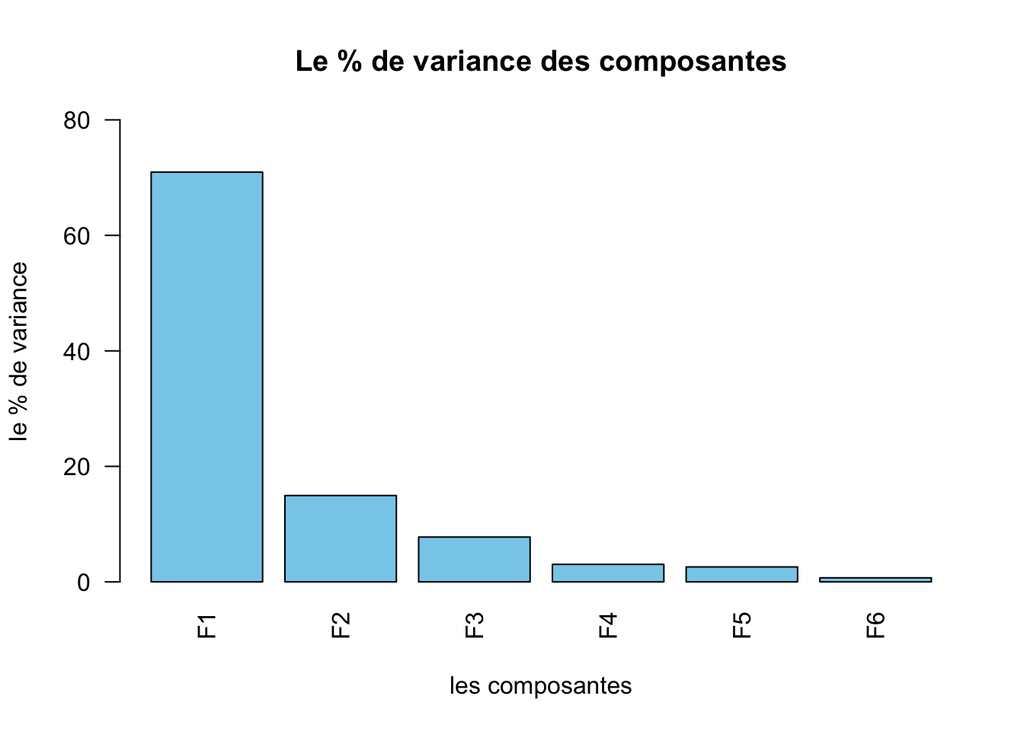

```r
VALPROP <- as.data.frame(Valprop)
VALPROP$Comp <- c("F1", "F2", "F3", "F4", "F5", "F6")
VALPROP <- VALPROP %>% rename(ValeurPropre='eigenvalue',
                    PCVariance='percentage of variance',
                    CumVariance='cumulative percentage of variance')
barplot(VALPROP$PCVariance,
        ylim = c(0, 80), col= "skyblue" ,
        names.arg = VALPROP$Comp,
      main = "Le % de variance des composantes",
     xlab = "les composantes",
     ylab = "le % de variance",
     las = 2)
```

### Analyse des variables / composantes

##### Qualités de représentation

- Extraction des qualités de représentations des variables sur les composantes (contenues dans *acp*)
- Récupération des qualités de représentations des variables sur les composantes dans un dataframe *Var$cos2*
- Nous n’analyserons que les 2 1ères composantes

```r
qualvar<-acp$var$cos2
QUALVAR <- as.data.frame(qualvar)
QUALVAR <- QUALVAR %>% select (Dim.1:Dim.2)
QUALVAR <- QUALVAR %>% rename(QualF1='Dim.1', QualF2='Dim.2')
kable(QUALVAR,
      digits=2,
      caption = "Qualités de représentations des variables sur les composantes")
```

Qualités de représentations des variables sur les composantes

|  | QualF1 | QualF2 |
| --- | --- | --- |
| tailm | 0.58 | 0.31 |
| logden | 0.66 | 0.23 |
| mobil | 0.73 | 0.00 |
| acmig | 0.63 | 0.14 |
| ordin | 0.95 | 0.01 |
| porta | 0.71 | 0.21 |

#### Contributions

*Var$contrib*

```r
ctrvar<-acp$var$contrib
CTRVAR <- as.data.frame(ctrvar)
CTRVAR <- CTRVAR %>% select (Dim.1:Dim.2)
CTRVAR <- CTRVAR %>% rename(CtrF1='Dim.1', CtrF2='Dim.2')
kable(CTRVAR,
      digits=2,
      caption = "Contributions des variables aux composantes")
```

Contributions des variables aux composantes

|  | CtrF1 | CtrF2 |
| --- | --- | --- |
| tailm | 13.68 | 34.86 |
| logden | 15.62 | 25.17 |
| mobil | 17.15 | 0.16 |
| acmig | 14.74 | 15.13 |
| ordin | 22.25 | 1.31 |
| porta | 16.57 | 23.37 |

#### Corrélations

```r
corvar<-acp$var$cor
CORVAR <- as.data.frame(corvar)
CORVAR <- CORVAR %>% select(Dim.1:Dim.2)
CORVAR <- CORVAR %>% rename(CorF1='Dim.1', CorF2='Dim.2')
kable(CORVAR,
      digits=2,
      caption = "Corrélations des variables avec les composantes")
```

Corrélations des variables avec les composantes

|  | CorF1 | CorF2 |
| --- | --- | --- |
| tailm | -0.76 | 0.56 |
| logden | 0.82 | -0.48 |
| mobil | 0.85 | 0.04 |
| acmig | 0.79 | 0.37 |
| ordin | 0.97 | 0.11 |
| porta | 0.84 | 0.46 |

#### Tableau de synthèse

Réunion des descriptions des variables (QUAL, COR, CTR) sur les composantes dans un seul tableau

```r
ACPComp <- cbind.data.frame(CORVAR, CTRVAR,QUALVAR)
kable(ACPComp,
      digits=2,
      caption = "Descriptions des composantes par les variables")
```

Descriptions des composantes par les variables

|  | CorF1 | CorF2 | CtrF1 | CtrF2 | QualF1 | QualF2 |
| --- | --- | --- | --- | --- | --- | --- |
| tailm | -0.76 | 0.56 | 13.68 | 34.86 | 0.58 | 0.31 |
| logden | 0.82 | -0.48 | 15.62 | 25.17 | 0.66 | 0.23 |
| mobil | 0.85 | 0.04 | 17.15 | 0.16 | 0.73 | 0.00 |
| acmig | 0.79 | 0.37 | 14.74 | 15.13 | 0.63 | 0.14 |
| ordin | 0.97 | 0.11 | 22.25 | 1.31 | 0.95 | 0.01 |
| porta | 0.84 | 0.46 | 16.57 | 23.37 | 0.71 | 0.21 |

#### Graphique n°1 : corrélations des variables avec les composantes

Représentation graphique des positions des variables sur le 1er plan factoriels : 1-2 soit 86% de la variance du tableau de données

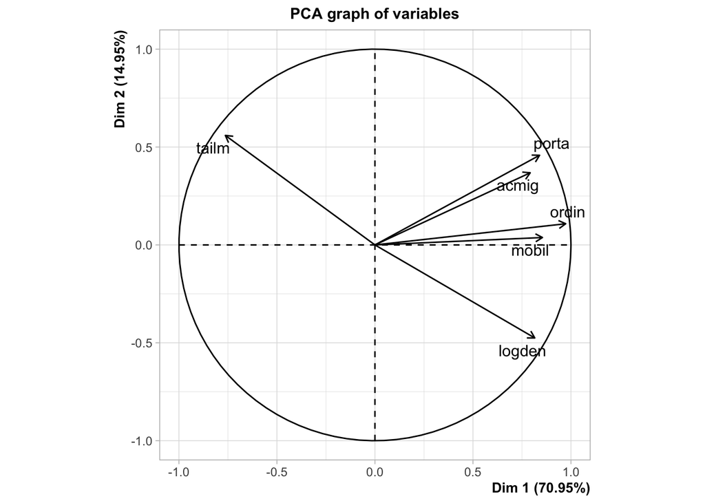

```r
plot.PCA(acp,choix = "var",axes = c(1,2))
```

### Analyse des individus / composantes

On fait la même chose pour les individus : on récupère les résultats pour les coordonnées et contributions des individus sur les composantes *ind$coord* *ind$contrib* On pourrait aussi récupérer les qualités de représentations (cos2) On ne travaille que sur les 2 premiers axes

#### Tableau de synthèse

```r
cooind<-data.frame(acp$ind$coord)
COOIND <- cooind %>% select(Dim.1:Dim.2)
COOIND <- COOIND %>% rename(CorIndF1='Dim.1', CorIndF2='Dim.2')

ctrind<-data.frame(acp$ind$contrib)
CTRIND <- ctrind %>% select(Dim.1:Dim.2)
CTRIND <- CTRIND %>% rename(CtrIndF1='Dim.1', CtrIndF2='Dim.2')

ACPIndComp <- cbind.data.frame(COOIND, CTRIND)
kable(ACPIndComp,
      digits=2,
      caption = "Descriptions des composantes par les variables")
```

|  | CorIndF1 | CorIndF2 | CtrIndF1 | CtrIndF2 |
| --- | --- | --- | --- | --- |
| AN | 4.78 | 0.59 | 22.40 | 1.62 |
| BA | 4.25 | 0.68 | 17.70 | 2.12 |
| BJ | -1.14 | -1.32 | 1.28 | 8.07 |
| BZ | -0.20 | -0.97 | 0.04 | 4.38 |
| GB | -0.21 | 0.70 | 0.04 | 2.25 |
| GF | -0.73 | 0.41 | 0.53 | 0.79 |
| JE | -1.07 | -1.32 | 1.11 | 8.05 |
| KB | -1.78 | 2.18 | 3.10 | 22.10 |
| KF | -1.05 | -1.32 | 1.08 | 8.14 |
| KR | -2.22 | -0.65 | 4.84 | 1.96 |
| KS | -2.42 | -0.19 | 5.72 | 0.16 |
| ME | -0.21 | 0.78 | 0.04 | 2.83 |
| MH | -0.88 | -0.17 | 0.76 | 0.14 |
| MN | 0.79 | 0.10 | 0.61 | 0.05 |
| MS | 1.60 | 0.32 | 2.51 | 0.48 |
| NB | 0.61 | -0.70 | 0.36 | 2.31 |
| SF | 1.32 | -0.21 | 1.71 | 0.20 |
| SL | -1.80 | -0.74 | 3.17 | 2.54 |
| SS | 2.39 | 0.49 | 5.60 | 1.12 |
| SZ | -2.20 | 0.05 | 4.73 | 0.01 |
| TA | -1.88 | 2.10 | 3.47 | 20.50 |
| TO | -0.90 | 0.61 | 0.79 | 1.71 |
| TU | 4.16 | -1.35 | 16.96 | 8.44 |
| ZA | -1.22 | -0.07 | 1.46 | 0.02 |

#### Graphique des coordonnées des individus sur les composantes

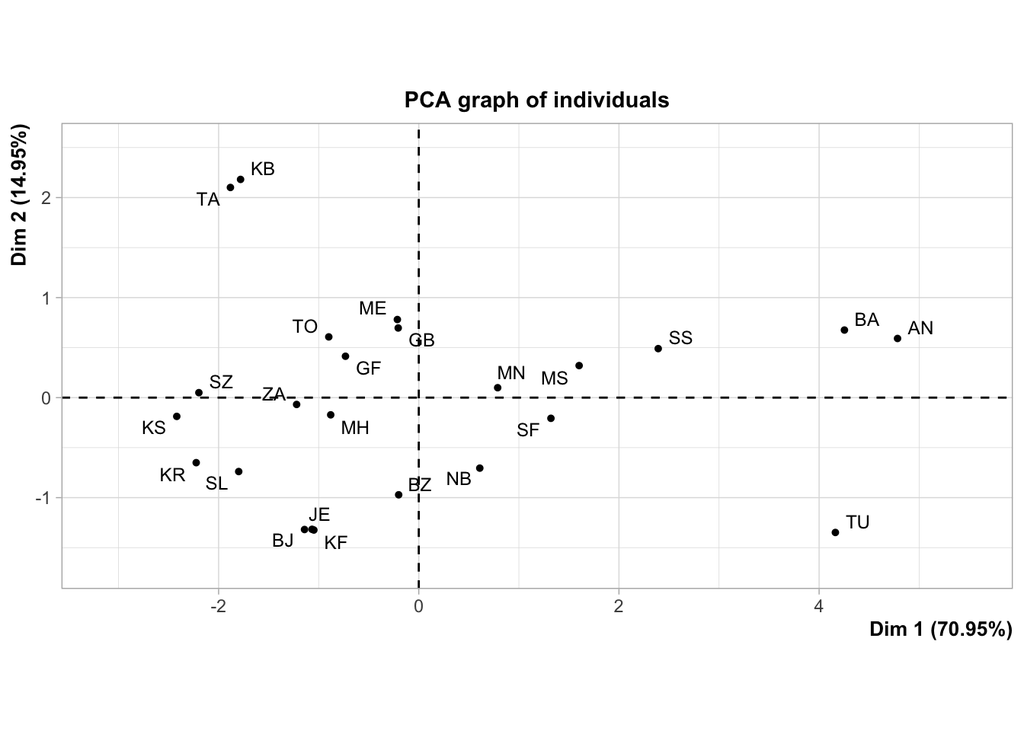

```r
plot.PCA(acp, choix = "ind",  cex = 0.8)
```

#### Cartographie des résultats de l’ACP

On fait une jointure

```r
# Chargement du fonds de carte
map<-readRDS("EXPLO/map2004.RDS")
map<-map[,c("gou_code","gou_nom","geometry")]
# Ajout du code aux résultats de l'ACP sur les individus
ACPIndComp$gou_code<-rownames(ACPIndComp)
# Jointure
mapACP<-merge(map,ACPIndComp,by="gou_code")
```

On cartographie l’axe factoriel n°1

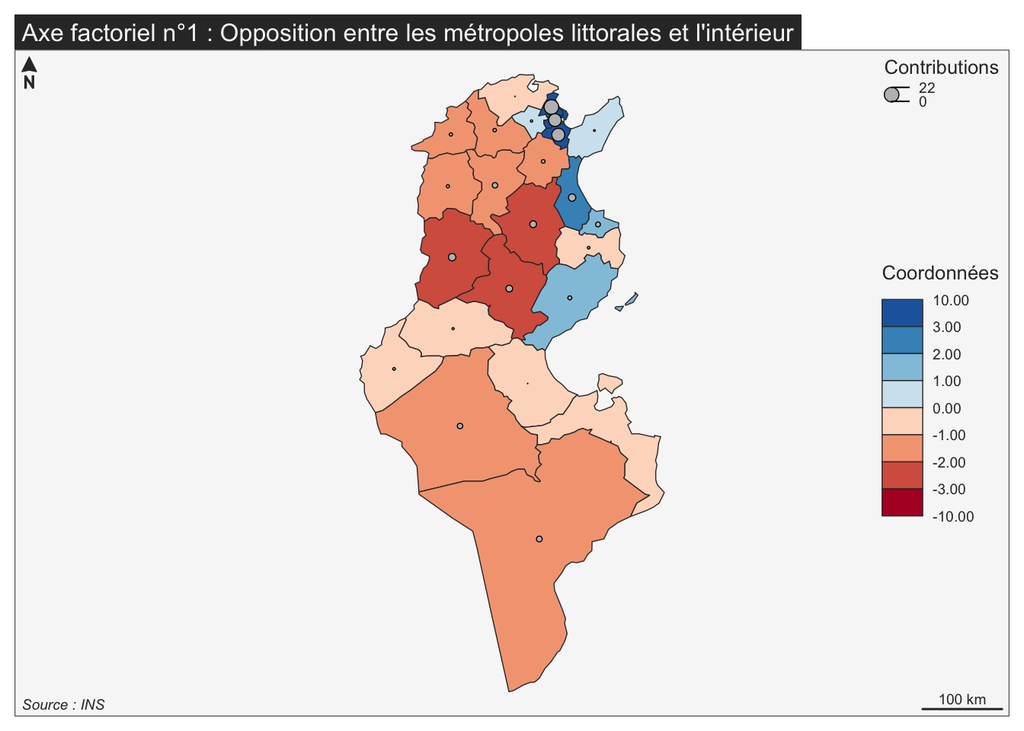

```r
# Choix des classes et paliers
mybreaks<-c(-10,-3,-2,-1,0,1,2,3,10)
mypal<-brewer.pal(n = 8,name="RdBu")

# Carte des coordonnées des individus sur le 1er axe
mf_map(x = mapACP, type = "choro",var="CorIndF1",
       breaks = mybreaks,
       pal=mypal,
       leg_title = "Coordonnées", leg_pos="right")
mf_map(x=mapACP, type="prop", var ="CtrIndF1",
       col="gray",border="black",inches=0.05,
       leg_title = "Contributions", leg_pos = "topright")
mf_layout(title =  "Axe factoriel n°1 : Opposition entre les métropoles littorales et l'intérieur",
          credits = "Source : INS",
          frame=T)
```

On cartographie l’axe factoriel n°2

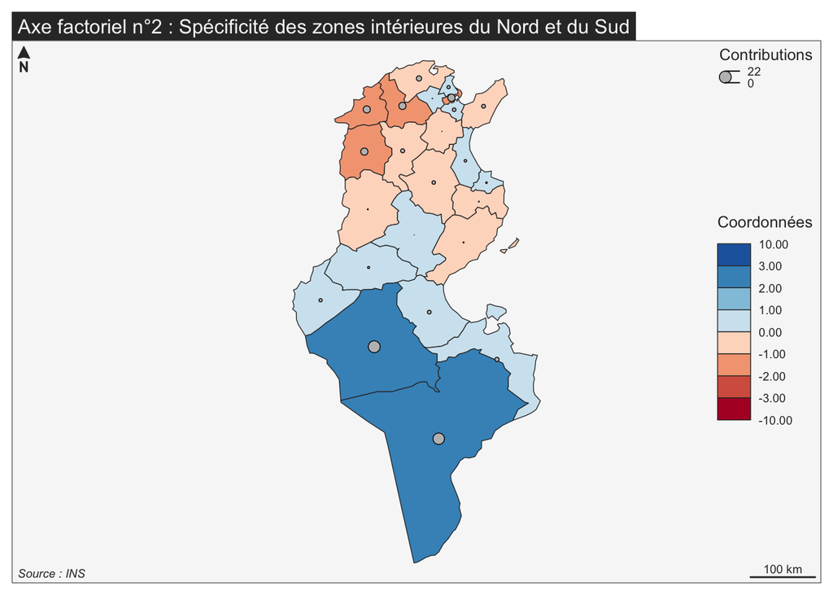

```r
# Choix des classes et paliers
mybreaks<-c(-10,-3,-2,-1,0,1,2,3,10)
mypal<-brewer.pal(n = 8,name="RdBu")

# Carte des coordonnées des individus sur le 1er axe
mf_map(x = mapACP, type = "choro",var="CorIndF2",
       breaks = mybreaks,
       pal=mypal,
       leg_title = "Coordonnées", leg_pos="right")
mf_map(x=mapACP, type="prop", var ="CtrIndF2",
       col="gray",border="black",inches=0.05,
       leg_title = "Contributions", leg_pos = "topright")
mf_layout(title = "Axe factoriel n°2 : Spécificité des zones intérieures du Nord et du Sud",
          credits = "Source : INS",
          frame=T)
```